# Ornek Teorisi

### 2-Q-Q Plot

qq-plotta sol taraf örnek dağılımını alt tarf teorik dağılımı ifade eder.

Örnek Dağılımı elimizde ki ölçümlerdir.

Teorik Dağılım ilgilenmiş olduğumuz normal dağılımdır.

```python
from matplotlib import pylab
from pylab import *
```

```
((array([-2.20385432, -1.83293478, -1.61402323, -1.45296849, -1.32267759,
         -1.21163342, -1.113805  , -1.02561527, -0.94475674, -0.86964726,
         -0.79915021, -0.73241807, -0.66879925, -0.6077796 , -0.54894415,
         -0.49195112, -0.43651377, -0.38238727, -0.32935914, -0.27724191,
         -0.2258675 , -0.17508277, -0.12474591, -0.07472335, -0.02488719,
          0.02488719,  0.07472335,  0.12474591,  0.17508277,  0.2258675 ,
          0.27724191,  0.32935914,  0.38238727,  0.43651377,  0.49195112,
          0.54894415,  0.6077796 ,  0.66879925,  0.73241807,  0.79915021,
          0.86964726,  0.94475674,  1.02561527,  1.113805  ,  1.21163342,
          1.32267759,  1.45296849,  1.61402323,  1.83293478,  2.20385432]),
  array([ 17,  50,  65,  75,  84,  95, 107, 110, 112, 114, 114, 119, 120,
         121, 127, 131, 135, 138, 145, 145, 145, 146, 149, 151, 154, 155,
         156, 157, 160, 163, 165, 166, 173, 177, 185, 187, 188, 197, 201,
         202, 203, 203, 207, 211, 216, 224, 225, 234, 244, 251])),
 (51.75136262507881, 154.38, 0.9929496595701188))
```

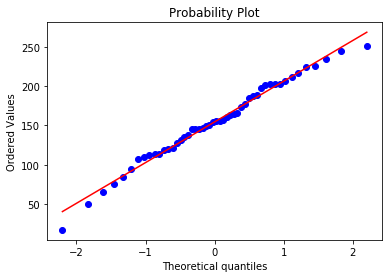

```python
import pylab
stats.probplot(olcumler,dist="norm",plot=pylab)
```

### Shapiro wilks Testi

H0: Örnek dağılımı ile teorik normal dağılım arasında istatiksel olarak anlamlı bir fark. yoktur.

H1: Örnek dağılımı ile teorik normal dağılım arasında istatiksel olarak anlamlı bir fark vardır

```python
from scipy.stats import shapiro
shapiro(olcumler)
```

```
(0.9853105545043945, 0.7848747968673706)
```

```python
print("T Hesap İstatistiği: " + str(shapiro(olcumler)[0]))
print("Hesaplanan P-value: " + str(shapiro(olcumler)[1]))
```

```
T Hesap İstatistiği: 0.9853105545043945
Hesaplanan P-value: 0.7848747968673706
```

ilk sonu t istatisği ikinci sonuç p-value değeri .

p-value>0.05 ise H0 reddedilemez.

NOrmal dağılım şartı sağlandığına göre tek örneklem t-testi kullanbilriz.

## Hipotez Testinin Uygulanması

```python
stats.ttest_1samp(olcumler,popmean=118)
```

```
Ttest_1sampResult(statistic=5.066443228721127, pvalue=6.157098518522443e-06)
```

H0:Web sitesinde geçirilen ortalama süre 118 dir H1:Web sitesinde geçirilen ortalama süre 118 ddeğildir. p-value<0.05 olduğundan H0 reddedilir.

## Nonparametrik Tek Örneklem Testi

```python
#varsayımlar sağlanmazsa non parametrik testler uygulanır.
from statsmodels.stats.descriptivestats import sign_test
#varsayım sağlanmazsa sign test uyguarız.
```

```python
sign_test(olcumler, 118)
```

```
(14.0, 9.021490107130607e-05)
```

Merkezi eğilim 118 olup olamdığını test ettik.

Dağılım çarpık olduğunda otalama ve parametrik testler kullanılamaz!!!

## Tek Örneklem Oran Testi

Oransal bir ifade test edilmek istenildiğinde kullanılır.

Hipotezler böyle olabilir:

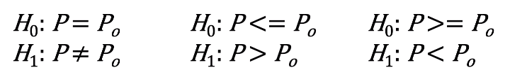

şart: n>30 olması

### Dönüşüm Oranı:

Örneğin bir ürünü 100 kişi gördü 1 kişi aldı.Dönüşüm oranı 1/100 dür.

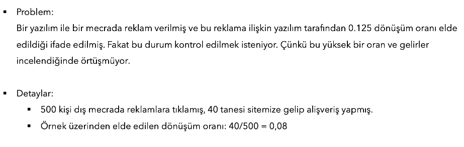

HO: p = 0.125

H1: p != 0.125 BUnu test edicez.

```python
from statsmodels.stats.proportion import proportions_ztest
```

```python
count = 40 #başarı sayısı
nobs = 500 #gözlem sayısı
value = 0.125 #test etmek istediğimiz değer

proportions_ztest(count, nobs, value)

print("T Hesap İstatistiği: " + str(proportions_ztest(count, nobs, value)[0]))
print("Hesaplanan P-value: " + str(proportions_ztest(count, nobs, value)[1]))
```

```
T Hesap İstatistiği: -3.7090151628513017
Hesaplanan P-value: 0.0002080669689845979
```

P-value<0.05 ise H0 reddedilir. Ürün satın alım oranı %95 güvenle ortalama dönüşüm oranı 0.125 değildir.

## Bağımsız İki Örneklem T Testi

H0: M1 = M2

H1: M1 != M2

İki grup ortalamaıs arasında karşılaştırma yapılmak istenildiğinde kullanılır .A/B test de denir.

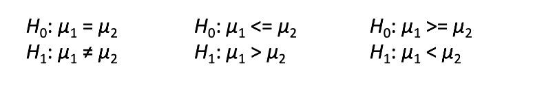

2 varsayım var:

1- Normallik

2- Varyans Homojenliği : Grupların varyansları birbirine bezner olmalıdırç

### ML modeli Başar Testi

A: eski sistemi temsil ediyor.

B:ML modeli kurulan yeni sitesimi temsil ediyor.

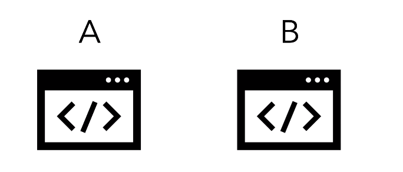

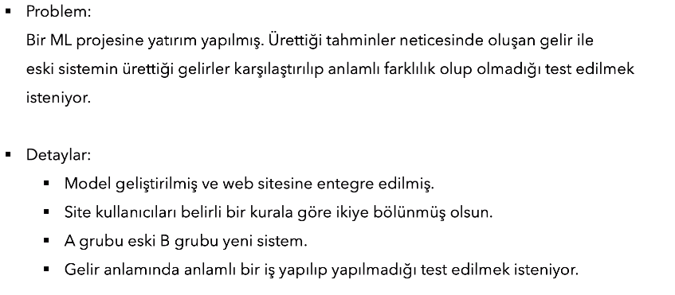

Machine learning projesi insanlara ürün öneriyor.

B grubuna yeni sisteme göre ürünler gösteriliyor.

Gelir anlamında anlamlı bir iş yapıldı mı yağılmadı mı ?

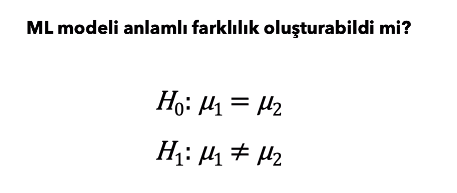

H0:Eski sistemin gösterileine göre insanlar ürün aldığında beliri bir süre zarfında ortaya çıkan gelirlerin ortalaması ile yeni sistemin önerilerinde göre iinsanlar ürün aldığında ortaya çıkan gelirlerin ortalaması eşittir.

H1:H0:Eski sistemin gösterileine göre insanlar ürün aldığında beliri bir süre zarfında ortaya çıkan gelirlerin ortalaması ile yeni sistemin önerilerinde göre iinsanlar ürün aldığında ortaya çıkan gelirlerin ortalaması eşit değildir.

# VERI TIPI I

Veri hata verir. Veri bu şekilde gelse bile veri dönüştürülmeli !!

```python
A = pd.DataFrame([30,27,21,27,29,30,20,20,27,32,35,22,24,23,25,27,23,27,23,
        25,21,18,24,26,33,26,27,28,19,25])

B = pd.DataFrame([37,39,31,31,34,38,30,36,29,28,38,28,37,37,30,32,31,31,27,
        32,33,33,33,31,32,33,26,32,33,29])


A_B = pd.concat([A, B], axis = 1)
A_B.columns = ["A","B"]

A_B.head()
```

|  | A | B |
| --- | --- | --- |
| 0 | 30 | 37 |
| 1 | 27 | 39 |
| 2 | 21 | 31 |
| 3 | 27 | 31 |
| 4 | 29 | 34 |

## Veri TİPİ2

```python
A = pd.DataFrame([30,27,21,27,29,30,20,20,27,32,35,22,24,23,25,27,23,27,23,
        25,21,18,24,26,33,26,27,28,19,25])

B = pd.DataFrame([37,39,31,31,34,38,30,36,29,28,38,28,37,37,30,32,31,31,27,
        32,33,33,33,31,32,33,26,32,33,29])

#A ve A'nın grubu
GRUP_A = np.arange(len(A))
GRUP_A = pd.DataFrame(GRUP_A)
GRUP_A[:] = "A"
A = pd.concat([A, GRUP_A], axis = 1)

#B ve B'nin Grubu
GRUP_B = np.arange(len(B))
GRUP_B = pd.DataFrame(GRUP_B)
GRUP_B[:] = "B"
B = pd.concat([B, GRUP_B], axis = 1)

#Tum veri
AB = pd.concat([A,B])
AB.columns = ["gelir","GRUP"]
print(AB.head())
print(AB.tail())
```

```
   gelir GRUP
0     30    A
1     27    A
2     21    A
3     27    A
4     29    A
    gelir GRUP
25     33    B
26     26    B
27     32    B
28     33    B
29     29    B
```

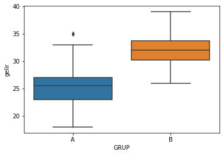

```python
import seaborn as sns
sns.boxplot(x = "GRUP", y = "gelir", data = AB);

#dağılım şans eseri mi değil mi bilmiyoruz.Varsayım kontrolulü yaparız.
```

## Varsayım Kontrolü

```python
#normallik varsayımında shapiro test yaparız.
A_B.head()
```

|  | A | B |
| --- | --- | --- |
| 0 | 30 | 37 |
| 1 | 27 | 39 |
| 2 | 21 | 31 |
| 3 | 27 | 31 |
| 4 | 29 | 34 |

#### #normallik varsayımı

```python
from scipy.stats import shapiro
```

```python
shapiro(A_B.A) #normallik varsyımı sağlanır.
```

```
(0.9789242148399353, 0.7962799668312073)
```

```python
shapiro(A_B.B) ##normallik varsyımı sağlanır.
```

```
(0.9561260342597961, 0.24584221839904785)
```

#### varyans homojenligi varsayımı

H0: Varyanslar Homojendir

H1: Varyanslar Homojen Değildir

```python
stats.levene(A_B.A, A_B.B)
```

```
LeveneResult(statistic=1.1101802757158004, pvalue=0.2964124900636569)
```

## Hipotez Testi

```python
stats.ttest_ind(A_B["A"], A_B["B"], equal_var = True)
```

```
Ttest_indResult(statistic=-7.028690967745927, pvalue=2.6233215605475075e-09)
```

```python
#H0 hipotezi reddedillir.
```

```python
test_istatistigi, pvalue = stats.ttest_ind(A_B["A"], A_B["B"], equal_var=True)
print('Test İstatistiği = %.4f, p-değeri = %.4f' % (test_istatistigi, pvalue))
```

```
Test İstatistiği = -7.0287, p-değeri = 0.0000
```

H1:Eski sistemin gösterileine göre insanlar ürün aldığında beliri bir süre zarfında ortaya çıkan gelirlerin ortalaması ile yeni sistemin önerilerinde göre iinsanlar ürün aldığında ortaya çıkan gelirlerin ortalaması eşit değildir.

Yani:

Ho reddedilir ML ile kurulan model anlamlı bir fark yartmıştır.

#### mannwhitneyu

testi non parametric testtir varsayımlar sağlanmadığında kullanılır.

## Nonparametrik Bağımsız İki Örneklem Testi

```python
stats.mannwhitneyu(A_B["A"],A_B["B"])
```

```
MannwhitneyuResult(statistic=89.5, pvalue=4.778975189306267e-08)
```

```python
test_istatistigi, pvalue = stats.mannwhitneyu(A_B["A"], A_B["B"])
print('Test İstatistiği = %.4f, p-değeri = %.4f' % (test_istatistigi, pvalue))
```

```
Test İstatistiği = 89.5000, p-değeri = 0.0000
```

## Bağımlı İki Örneklem T Testi

Bağımlı iki grup ortalamaları arasında karşılaştırma yapılmak istenildiğinde kullanılır.

Burda bir kitle vadır öncesi ve sonrası karşılaştırılır.

2 varsayım var :

1)Normallik 2)Varyans Homojenliği

### Örnek :Şirket içi Eğitimin Performans Etkisi Ölçümü

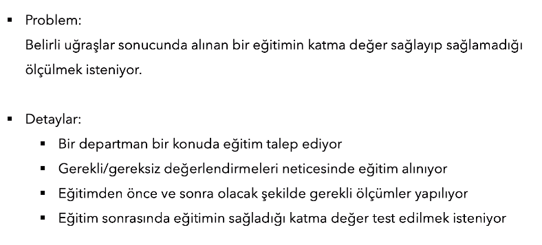

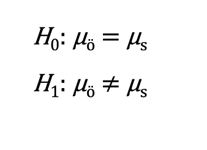

```python
oncesi = pd.DataFrame([123,119,119,116,123,123,121,120,117,118,121,121,123,119,
            121,118,124,121,125,115,115,119,118,121,117,117,120,120,
            121,117,118,117,123,118,124,121,115,118,125,115])

sonrasi = pd.DataFrame([118,127,122,132,129,123,129,132,128,130,128,138,140,130,
             134,134,124,140,134,129,129,138,134,124,122,126,133,127,
             130,130,130,132,117,130,125,129,133,120,127,123])
```

```python
oncesi[0:5]
```

|  | 0 |
| --- | --- |
| 0 | 123 |
| 1 | 119 |
| 2 | 119 |
| 3 | 116 |
| 4 | 123 |

```python
sonrasi[0:5]
```

|  | 0 |
| --- | --- |
| 0 | 118 |
| 1 | 127 |
| 2 | 122 |
| 3 | 132 |
| 4 | 129 |

```python
 np.arange(len(oncesi))
```

```
array([ 0,  1,  2,  3,  4,  5,  6,  7,  8,  9, 10, 11, 12, 13, 14, 15, 16,
       17, 18, 19, 20, 21, 22, 23, 24, 25, 26, 27, 28, 29, 30, 31, 32, 33,
       34, 35, 36, 37, 38, 39])
```

```python
#BIRINCI VERI SETI
AYRIK = pd.concat([oncesi, sonrasi], axis = 1)
AYRIK.columns = ["ONCESI","SONRASI"]
print("'AYRIK' Veri Seti: \n\n ", AYRIK.head(), "\n\n")


#IKINCI VERI SETI
#ONCESI FLAG/TAG'INI OLUSTURMA
GRUP_ONCESI = np.arange(len(oncesi))
GRUP_ONCESI = pd.DataFrame(GRUP_ONCESI)
GRUP_ONCESI[:] = "ONCESI"
#FLAG VE ONCESI DEGERLERINI BIR ARAYA GETIRME
A = pd.concat([oncesi, GRUP_ONCESI], axis = 1)
#SONRASI FLAG/TAG'INI OLUSTURMA
GRUP_SONRASI = np.arange(len(sonrasi))
GRUP_SONRASI = pd.DataFrame(GRUP_SONRASI)
GRUP_SONRASI[:] = "SONRASI"

#FLAG VE SONRASI DEGERLERINI BIR ARAYA GETIRME
B = pd.concat([sonrasi, GRUP_SONRASI], axis = 1)

#TUM VERIYI BIR ARAYA GETIRME
BIRLIKTE = pd.concat([A,B])
BIRLIKTE

#ISIMLENDIRME
BIRLIKTE.columns = ["PERFORMANS","ONCESI_SONRASI"]
print("'BIRLIKTE' Veri Seti: \n\n", BIRLIKTE.head(), "\n")
```

```
'AYRIK' Veri Seti:

     ONCESI  SONRASI
0     123      118
1     119      127
2     119      122
3     116      132
4     123      129


'BIRLIKTE' Veri Seti:

    PERFORMANS ONCESI_SONRASI
0         123         ONCESI
1         119         ONCESI
2         119         ONCESI
3         116         ONCESI
4         123         ONCESI
```

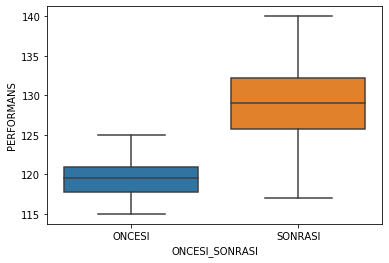

```python
sns.boxplot(x = "ONCESI_SONRASI", y = "PERFORMANS", data = BIRLIKTE);
€ğitim işe yaramış gözüküyor istatiksel bilgiye başvurmadan .
Testler yaparak doğrulamaya çalışırız,ama önce varsayım kontrolü yapmalıyız.
```

## Varsayım Kontrolleri

```python
from scipy.stats import shapiro
```

```python
shapiro(AYRIK.ONCESI)
```

```
(0.9543656706809998, 0.10722451657056808)
```

```python
shapiro(AYRIK.SONRASI)
```

```
(0.9780089259147644, 0.6159515380859375)
```

```python
import scipy.stats as stats
stats.levene(AYRIK.ONCESI, AYRIK.SONRASI)
#varyanslar homojen mi test ettik .
#H0 reddedildi. Varyanslar Homojen değildir.
#Varsayım bozuldu.
#Varsayım sağlanmazsa gözardı edebiliriz bu testi ve devam edebiliriz(hipotez testine).
#Non-parametrik testi de uygulayabiliriz.
```

```
LeveneResult(statistic=8.31303288672351, pvalue=0.0050844511807370246)
```

## Hipotez Testi

```python
stats.ttest_rel(AYRIK.ONCESI, AYRIK.SONRASI)

#Ho reddedildi.Eğitim işe yaramıştır.
```

```
Ttest_relResult(statistic=-9.281533480429937, pvalue=2.0235251764440722e-11)
```

```python
print('Test İstatistiği = %.5f, p-değeri = %.5f' % (test_istatistigi, pvalue))
```

[output not shown]

## Nonparametrik Bağımlı İki Örneklem Testi

```python
stats.wilcoxon(AYRIK.ONCESI, AYRIK.SONRASI)
#varsayımlar sağlanmazsa Wilcoxon testi yapılırç Non parametrik bağımlı iki örneklem testi için kullanılır.

#H0 reddedilir ,ortalamalar faklıdır.
```

```
WilcoxonResult(statistic=15.0, pvalue=2.491492033374464e-07)
```

```python
test_istatistigi, pvalue = stats.wilcoxon(AYRIK["ONCESI"], AYRIK["SONRASI"])

print('Test İstatistiği = %.4f, p-değeri = %.4f' % (test_istatistigi, pvalue))
```

```
Test İstatistiği = 15.0000, p-değeri = 0.0000
```

## İki Örneklem Oran Testi

```python
# Varsayımı n>30 olması
from statsmodels.stats.proportion import proportions_ztest
#iki oran arasında karşılaştırmak şeklinde kullanılır.
```

Hipotezleri böyle olabilir.

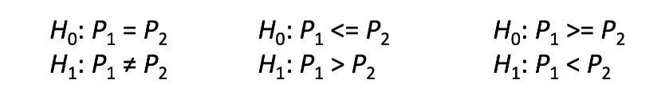

## Kullanıcı arayüzü deneyi

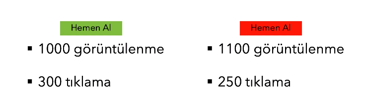

```python
from statsmodels.stats.proportion import proportions_ztest
import numpy as np
basari_sayisi = np.array([300, 250])
gozlem_sayilari = np.array([1000, 1100])
```

```python
proportions_ztest(count = basari_sayisi, nobs = gozlem_sayilari)

# P value<0.05 olduğğunda H0 reddedilir.
#Birinci buton renk ile ikinci renk buton  arasında kullanıcı davranışları arasında istatiksel olarak anlamlı fark
#vardır.Yeşil Buton seçilir.
```

```
(3.7857863233209255, 0.0001532232957772221)
```

### Varyans Analizi

2 den fazla grup ortalaması arasında istatiksel olarak anlamlı bir fark olup olmadığı öğrenilmek istenildiğinde kullanılır.

#### Hipotezler:

H0: M1 = M2 = M3 (grup ortalamalari arasinda istatiksel olarak anlamlı farklilik yoktur)

H1: Fark vardir.

```python
A = pd.DataFrame([28,33,30,29,28,29,27,31,30,32,28,33,25,29,27,31,31,30,31,34,30,32,31,34,28,32,31,28,33,29])

B = pd.DataFrame([31,32,30,30,33,32,34,27,36,30,31,30,38,29,30,34,34,31,35,35,33,30,28,29,26,37,31,28,34,33])

C = pd.DataFrame([40,33,38,41,42,43,38,35,39,39,36,34,35,40,38,36,39,36,33,35,38,35,40,40,39,38,38,43,40,42])

dfs = [A, B, C]

ABC = pd.concat(dfs, axis = 1)
ABC.columns = ["GRUP_A","GRUP_B","GRUP_C"]
ABC.head()
```

|  | GRUP_A | GRUP_B | GRUP_C |
| --- | --- | --- | --- |
| 0 | 28 | 31 | 40 |
| 1 | 33 | 32 | 33 |
| 2 | 30 | 30 | 38 |
| 3 | 29 | 30 | 41 |
| 4 | 28 | 33 | 42 |

## Varsayım Kontrolü

#### Varsayımlar:

1)Gözlemlerin birbirinden bağımsız olması

2)Varyans Homojenliği

3)Normal dağılım

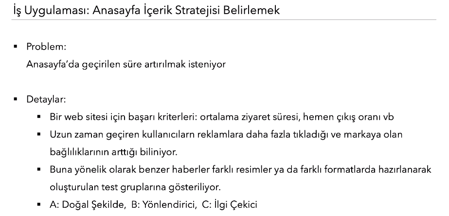

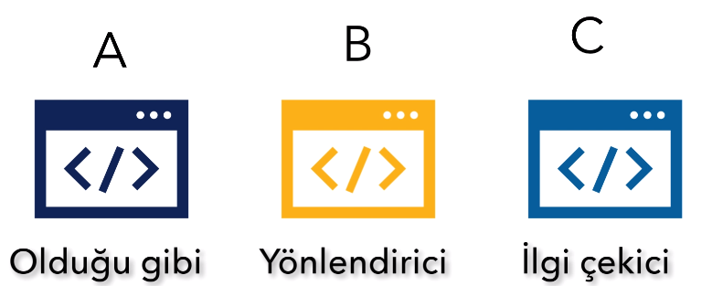

```python
#kullanıcılar 3 gruba bölündü ve kullanıcılar sadece bir gruba katıldı
#yani gruplar birbirinden bağımsız şarı sağlandı
```

```python
from scipy.stats import shapiro #normallik varsayımı
```

```python
shapiro(ABC["GRUP_A"])
```

```
(0.969743549823761, 0.5321813225746155)
```

```python
shapiro(ABC["GRUP_B"])
```

```
(0.9789854884147644, 0.7979801297187805)
```

```python
shapiro(ABC["GRUP_C"]) #3 grup içinde normallik varsayımı sağlandı.
```

```
(0.9579201340675354, 0.273820161819458)
```

```python
stats.levene(ABC["GRUP_A"], ABC["GRUP_B"],ABC["GRUP_C"]) #varyanslar homojendir
# 3 varsayım sağlanmış oldu.
```

```
LeveneResult(statistic=1.0267403645055275, pvalue=0.36247110117417064)
```

## Hipotez Testi

```python
from scipy.stats import f_oneway
```

```python
f_oneway(ABC["GRUP_A"], ABC["GRUP_B"],ABC["GRUP_C"])
#H0 reddedilir.
#gruplar arası istatistiksel olarak anlamlı bir fark vardır.
```

```
F_onewayResult(statistic=74.69278140730431, pvalue=1.3079050746811477e-19)
```

```python
print('{:.5f}'.format(f_oneway(ABC["GRUP_A"], ABC["GRUP_B"],ABC["GRUP_C"])[1]))
```

```
0.00000
```

```python
ABC.describe().T
#istatiski olarak Grup-C nin diğer gruplara göre daha anlamlı katkı sağlayabileceği kanıtlanmıştır.
```

|  | count | mean | std | min | 25% | 50% | 75% | max |
| --- | --- | --- | --- | --- | --- | --- | --- | --- |
| GRUP_A | 30.0 | 30.133333 | 2.224214 | 25.0 | 28.25 | 30.0 | 31.75 | 34.0 |
| GRUP_B | 30.0 | 31.700000 | 2.937862 | 26.0 | 30.00 | 31.0 | 34.00 | 38.0 |
| GRUP_C | 30.0 | 38.100000 | 2.808239 | 33.0 | 36.00 | 38.0 | 40.00 | 43.0 |

## Nonparametrik Hipotez Testi

# varsayımlarsağlanmazsa nonparametrik testler kullanılır.

```python
from scipy.stats import kruskal
```

```python
kruskal(ABC["GRUP_A"], ABC["GRUP_B"],ABC["GRUP_C"])
```

```
KruskalResult(statistic=54.19819735523783, pvalue=1.7022015426175926e-12)
```

p-value<0.05 H0 reddedilir.Gruplar arası en az biri diğerlerinden farklıdır.Gruplar arası istatistiksel olarak anlamlı bir farklılık vardır.

## Korelasyon Analizi

Değişkenler arası ilişki bu ilişkinin yönü ve şiddeti ile ilgli bilgiler sağlayan istatiksel yöntemdir.

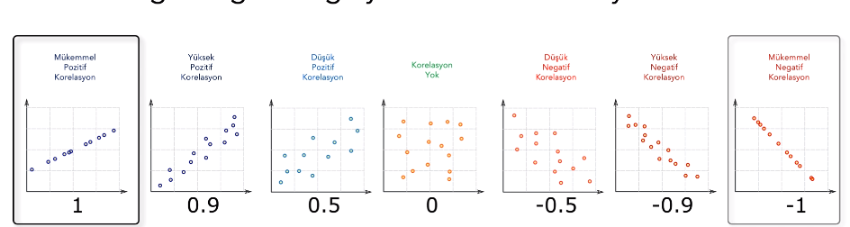

#### Korelasyon Hipotezi:

```
Korelasyonu anlamlılığının Testi: Bulunan korelasyon anlamlı mı?

    H0:P=0 # Değişkenler arası korelasyon yoktur.
    Ha:P!=0 #DEğişkenler arası anlamlı ilşkisi vardır.

    H0 reddedilmesi beklenir. kurulacak testte.
```

## Varsayım şartları : Normal dağılım şartı sağlanırsa pearson Korelasyon katsayısı sağlanmazsa spearman korelasyon katsayısı

## Hesap ile Bahşiş arasındaki ilişki

Bahşiş veri seti:

total_bill: yemeğin toplam fiyatı (bahşiş ve vergi dahil)

tip: bahşiş

sex: ücreti ödeyen kişinin cinsiyeti (0=male, 1=female)

smoker: grupta sigara içen var mı? (0=No, 1=Yes)

day: gün (3=Thur, 4=Fri, 5=Sat, 6=Sun)

time: ne zaman? (0=Day, 1=Night)

size: grupta kaç kişi var?

```python
import seaborn as sns
tips = sns.load_dataset('tips')
df = tips.copy()
df.head()
```

|  | total_bill | tip | sex | smoker | day | time | size |
| --- | --- | --- | --- | --- | --- | --- | --- |
| 0 | 16.99 | 1.01 | Female | No | Sun | Dinner | 2 |
| 1 | 10.34 | 1.66 | Male | No | Sun | Dinner | 3 |
| 2 | 21.01 | 3.50 | Male | No | Sun | Dinner | 3 |
| 3 | 23.68 | 3.31 | Male | No | Sun | Dinner | 2 |
| 4 | 24.59 | 3.61 | Female | No | Sun | Dinner | 4 |

```python
df["total_bill"] = df["total_bill"] - df["tip"] #yemeğin masrafı
```

```python
df.head()
```

|  | total_bill | tip | sex | smoker | day | time | size |
| --- | --- | --- | --- | --- | --- | --- | --- |
| 0 | 15.98 | 1.01 | Female | No | Sun | Dinner | 2 |
| 1 | 8.68 | 1.66 | Male | No | Sun | Dinner | 3 |
| 2 | 17.51 | 3.50 | Male | No | Sun | Dinner | 3 |
| 3 | 20.37 | 3.31 | Male | No | Sun | Dinner | 2 |
| 4 | 20.98 | 3.61 | Female | No | Sun | Dinner | 4 |

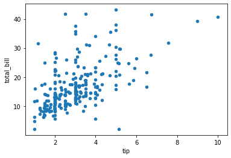

```python
df.plot.scatter("tip","total_bill");
```

### Varsayım kontrolu

```python
from scipy.stats import shapiro
```

```python
test_istatistigi,pvalue=shapiro(df["tip"])
print("Test istatistiği:%.4f,p-değeri:%.4f"% (test_istatistigi,pvalue))
```

```
Test istatistiği:0.8978,p-değeri:0.0000
```

```python
test_istatistigi,pvalue=shapiro(df["total_bill"])
print("Test istatistiği:%.4f,p-değeri:%.4f"% (test_istatistigi,pvalue))
```

```
Test istatistiği:0.9136,p-değeri:0.0000
```

# Normallik varsayımı her iki değişken için sağlanmamaktadır.H0 red.

# Hipotez Testi

### Korelasyon Katsayısı

```python
#pearson korelasyon katsayısı:
df["tip"].corr(df["total_bill"])
```

```
0.5766634471096375
```

```python
df["tip"].corr(df["total_bill"],method="spearman") #değişkenler arsında pozitif yönlü orta şiddetli ilşki var.
```

```
0.593691939408997
```

```python
df["total_bill"].corr(df["tip"],method="spearman")
```

```
0.593691939408997
```

### Korelasyonunu Anlamlılığının Testi

```python
from scipy.stats.stats import pearsonr
```

```python
test_istatistigi, pvalue = pearsonr(df["tip"],df["total_bill"])
print('Korelasyon Katsayısı = %.4f, p-değeri = %.4f' % (test_istatistigi, pvalue))
```

```
Korelasyon Katsayısı = 0.5767, p-değeri = 0.0000
```

### Nonparametrik Hipotez Testi

```python
from scipy.stats import stats
stats.spearmanr(df["tip"],df["total_bill"])

test_istatistigi, pvalue = stats.spearmanr(df["tip"],df["total_bill"])

print('Korelasyon Katsayısı = %.4f, p-değeri = %.4f' % (test_istatistigi, pvalue))
```

```
Korelasyon Katsayısı = 0.5937, p-değeri = 0.0000
```